# Assignement 4

Sofia Davoli

6/6/2020

# 1. The decision tree

```r
treeAss = yaml.load_file(input = "C:/Users/davol/Documents/Magistrale/decision models/assignement/tree-Ass.yaml")
result = dtree(yl = treeAss)
plot(result, final = FALSE)
```

[interactive chart not shown]

# 2. Expected value

```r
plot(result, final = TRUE)
```

[interactive chart not shown]

Using Expected Value we prefer to buy all the chips from KR Electronics company, since the expected price is lower than the other 2 options.

# 3. Sensitivity analysis

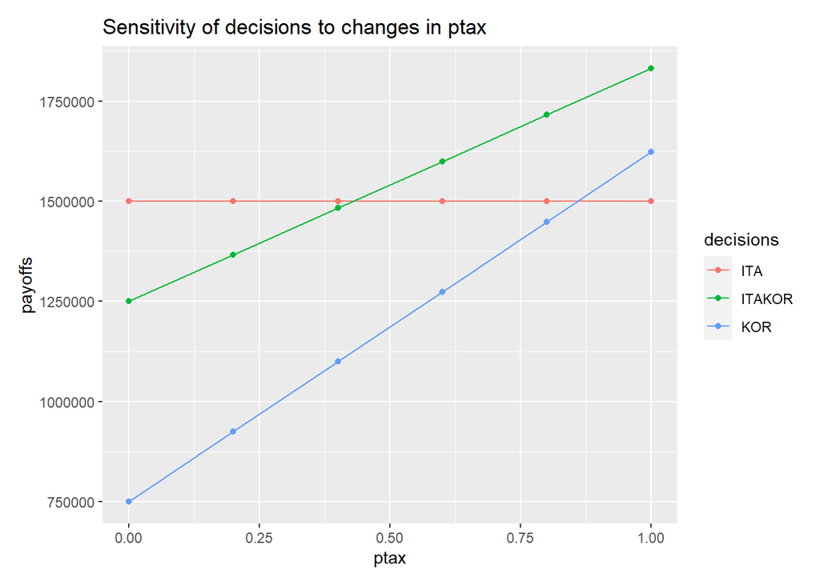

```r
sensitivity(
  result,
  vars = "ptax 0 1 0.2;",
  decs = c("ITA", "ITAKOR", "KOR"),
  custom = FALSE)
```

# 4. Utility Function and Certainty Equivalent

```r
cost <- as.data.frame(cbind(rep(1500000, 4),
                            c(1250000, 1500000, 1750000, 2250000),
                            c(750000, 1125000, 1500000, 2250000)
              ))
colnames(cost) <- c("ITA","ITA-KOR","KOR")
cost
```

| ITA | ITA-KOR | KOR |
| --- | --- | --- |
| 1500000 | 1250000 | 750000 |
| 1500000 | 1500000 | 1125000 |
| 1500000 | 1750000 | 1500000 |
| 1500000 | 2250000 | 2250000 |

```r
utilityFunctionExp <- function(X, R = 750000) {
  res <- 1- exp(-X/R)
  return(res)
}

CertEquivalent = function(EU, R){
  CE = -R*ln(1-EU)
  return(CE)
}

CalcExpectedUtilityFunction = function(cost, R = 750000){
  UF1 = utilityFunctionExp(cost$ITA, R)[1]
  #________________________________________________________________________
  UF2 = utilityFunctionExp(cost$`ITA-KOR`, R)
  UF2_A = 0.333*UF2[2]+0.333*UF2[3]+ 0.333*UF2[4]
  UF2_B = max(UF2_A, UF2[1])
  #________________________________________________________________________
  UF3 = utilityFunctionExp(cost$KOR, R)
  UF3_A = 0.333*UF3[2]+0.333*UF3[3]+ 0.333*UF3[4]
  UF3_B = max(UF3_A, UF3[1])

  return (c(UF1, UF2_B, UF3_B))
}

CalcExpectedUtilityFunction(cost = cost)
```

```
## [1] 0.8646647 0.9050626 0.8630519
```

Korean and Italian Utility Function are the less risky option. Theyr UF falue are close cause the 2 option are almost equals. In this case we still prefer to buy From Korean company.

```r
CalcBranchCE = function(cost, R){
  CE_vett = CertEquivalent(CalcExpectedUtilityFunction(cost, R), R)
  return(CE_vett)
}

CalcBranchCE(cost = cost, R = 750000)
```

```
## [1] 1500000 1765903 1491115
```

To avoid risk we can buy for a $1491115 price

# 5. KR revises the offer and Value of Information

```r
treeAssrevised = yaml.load_file(input = "C:/Users/davol/Documents/Magistrale/decision models/assignement/tree-Ass-revised.yaml")
```

```r
result = dtree(yl = treeAssrevised, opt = "min")
plot(result, final = TRUE)
```

[interactive chart not shown]

If the charge by italian governement:

- is zero: buy from korean for $750000
- is 50%: buy from korean for $1125000
- is 100% buy from koeran or from italy (same price) for $1500000
- is 200% buy from italy for $1500000 In this case EV is obtained as **750000*0.4 + 1125000*0.6*0.3 + 1500000*0.6*0.3 + 1500000*0.6*0.3**

**1244055 - 1042500 = 201555** is the value of perfect information